### Part II

#### Solution

Tuesday, May 19, 2015

**2.** This problem concerns the analysis of 1990 salary data for a random sample of $n=30$ offensive backs in the NFL. Data can be found in the file `salary.txt`. The variables available for modeling were:

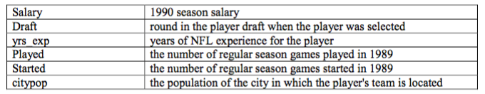

```r
raw.text <- "
Rows    salary  Draft   yrs_exp played  started citypop
1   236000  1   2   16  16  2737000
2   250000  6   5   16  5   2737000
3   185000  10  4   16  16  4620000
4   165000  13  2   6   0   4620000
5   250000  1   3   16  4   13770000
6   300000  11  7   16  13  13770000
7   300000  3   7   11  8   2388000
8   1000000 8   10  14  12  2388000
9   225000  13  5   11  7   1307000
10  475000  7   6   16  15  1307000
11  425000  3   7   16  1   18120000
12  310000  8   6   16  0   18120000
13  287500  4   4   13  10  18120000
14  700000  1   5   16  15  5963000
15  1275000 2   6   16  16  5963000
16  185000  12  5   15  1   2030000
17  700000  1   2   2   1   2030000
18  325000  4   6   16  1   2030000
19  155000  3   2   7   0   6042000
20  500000  3   2   8   6   1995000
21  204000  2   2   13  1   1995000
22  1366700 1   4   14  14  1995000
23  160000  3   2   14  0   1176000
24  1050000 1   10  16  14  1728000
25  98000   7   2   11  0   1728000
26  370000  3   2   10  1   3641000
27  450000  2   6   16  8   1237000
28  195000  2   1   1   0   1575000
29  1500000 1   8   16  16  3001000
30  420000  8   13  14  0   4110000
"
salary.df <- read.table(header=TRUE, text=raw.text)
```

1. Plot *salary* vs. *draft* and *log-salary* vs. *draft*. Make a sketch below based on SAS/R output. What do the plots suggest (as far as using standard statistical methodology is concerned) that *log-salary* is probability a better “$y$” than *salary*? (log - Natural Logarithm)  
   **Solution**

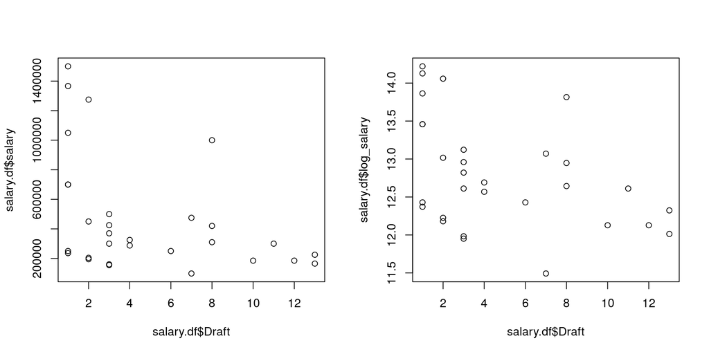

```r
salary.df$log_salary <- log(salary.df$salary) # new column for log salary
par(mfrow=c(1,2))
plot(x=salary.df$Draft, y=salary.df$salary) # Salary vs. Draft
plot(x=salary.df$Draft, y=salary.df$log_salary) # Log-salary vs. Draft
```

“The variability in salary is a lot large for the athlete who got drafted first. A log transformation helps to stabilize the variance.”

2. Create a new variable *draft_inv = 1/draft*. Fit a Simple Linear Regression (SLR) using the model *log-salary* $= \beta_0 + \beta_1 draft\_inv + \epsilon$. Write down the fitted model and make interpretations of the estimates.  
   **Soution**

```r
salary.df$draft_inv <- 1/salary.df$Draft

salary.inv.lm <- lm(formula=log_salary ~ draft_inv, data=salary.df)
summary(salary.inv.lm)
```

```
##
## Call:
## lm(formula = log_salary ~ draft_inv, data = salary.df)
##
## Residuals:
##      Min       1Q   Median       3Q      Max
## -1.02858 -0.38572  0.05867  0.38809  1.34265
##
## Coefficients:
##             Estimate Std. Error t value Pr(>|t|)
## (Intercept)  12.3404     0.1815  67.996  < 2e-16 ***
## draft_inv     1.0598     0.3324   3.188  0.00351 **
## ---
## Signif. codes:  0 '***' 0.001 '**' 0.01 '*' 0.05 '.' 0.1 ' ' 1
##
## Residual standard error: 0.6237 on 28 degrees of freedom
## Multiple R-squared:  0.2664, Adjusted R-squared:  0.2402
## F-statistic: 10.17 on 1 and 28 DF,  p-value: 0.003506
```

Model: $\widehat{log\_salary} = 12.34 + 1.059 \frac{1}{draft}$ Interpretation:

3. What does the SLR model in (b) give as the difference in mean *log-salary* values for $1^{st}$ and $2^{nd}$ round draft picks? Give 95% confidence limits for this difference in means.  
   **Solution**  
   General model: $log\_salary_{draft \ no.} = \beta_0 + \beta_1 \frac{1}{draft}$  
   $log\_salary_{(1st)} = \beta_0 + \beta_1 \frac{1}{1}$  
   $log\_salary_{(2nd)} = \beta_0 + \beta_1 \frac{1}{2}$  
   The difference in means: $log\_salary_{(1st)} - log\_salary_{(2nd)} = (\beta_0 + \beta_1) - \Big(\beta_0 + \frac{1}{2}\beta_1\Big) = \frac{1}{2}\beta_1$ The difference is a function of parameter $\beta_1$. The variance of the difference in means: $\text{Var}\left( \frac{1}{2} \beta_1 \right) = \frac{1}{4} \text{Var} (\beta_1) = \frac{1}{4} \sigma^2_{\beta}$ 95% CI for difference in means: $\begin{gather} \frac{1}{2}\beta_1 \pm t_{.975, 28}\cdot \sqrt{\frac{1}{4}s^2_{\beta_1}} \\ \frac{1}{2}\beta_1 \pm t_{.975, 28}\cdot \frac{1}{2}s_{\beta_1} \\ \frac{1}{2} \cdot 1.059 \pm 2.048 \frac{0.332}{2} = (0.1895, 0.8695) \end{gather}$
4. Now consider Multiple Linear Regression of *log-salary*, with terms *draft_inv*, *yrs_exp*, *played*, *started*, *citypop*, and percent started $\big(\frac{\text{started}}{\text{played}}\big)$. Use a stepwise forward selection to find the “best” sub-model ($\alpha=0.1$). Write down your final fitted model and use it for (e). Check the model assumptions (do NOT change your answers regardless of model assumption results).  
   **Solution**  
   First, create a new column in our data frame to include percent started:

```r
# pct_start variable must be added in data frame.
# Dividing it inside the `lm()` function implies nesting
salary.df$pct_start <- salary.df$started/salary.df$played
```

For forward stepwise regression use this function (source: http://orinanobworld.blogspot.ca/2011/02/stepwise-regression-in-r.html):

```r
#
# This is an R function to perform stepwise regression based on a "nested model" F test for inclusion/exclusion
# of a predictor.  To keep it simple, I made no provision for forcing certain variables to be included in
# all models, did not allow for specification of a data frame, and skipped some consistency checks (such as whether
# the initial model is a subset of the full model).
#
# One other note: since the code uses R's drop1 and add1 functions, it respects hierarchy in models. That is,
# regardless of p values, it will not attempt to drop a term while retaining a higher order interaction
# involving that term, nor will it add an interaction term if the lower order components are not all present.
# (You can of course defeat this by putting interactions into new variables and feeding it what looks like
# a first-order model.)
#
# Consider this to be "beta" code (and feel free to improve it).  I've done very limited testing on it.
#
# Author: Paul A. Rubin (rubin@msu.edu)
#
stepwise <- function(full.model, initial.model, alpha.to.enter, alpha.to.leave) {
  # full.model is the model containing all possible terms
  # initial.model is the first model to consider
  # alpha.to.enter is the significance level above which a variable may enter the model
  # alpha.to.leave is the significance level below which a variable may be deleted from the model
  # (Useful things for someone to add: specification of a data frame; a list of variables that must be included)
  full <- lm(full.model);  # fit the full model
  msef <- (summary(full)$sigma)^2;  # MSE of full model
  n <- length(full$residuals);  # sample size
  allvars <- attr(full$terms, "predvars");  # this gets a list of all predictor variables
  current <- lm(initial.model);  # this is the current model
  while (TRUE) {  # process each model until we break out of the loop
    temp <- summary(current);  # summary output for the current model
    rnames <- rownames(temp$coefficients);  # list of terms in the current model
    print(temp$coefficients);  # write the model description
    p <- dim(temp$coefficients)[1];  # current model's size
    mse <- (temp$sigma)^2;  # MSE for current model
    cp <- (n-p)*mse/msef - (n-2*p);  # Mallow's cp
    fit <- sprintf("\nS = %f, R-sq = %f, R-sq(adj) = %f, C-p = %f",
                   temp$sigma, temp$r.squared, temp$adj.r.squared, cp);
    write(fit, file="");  # show the fit
    write("=====", file="");  # print a separator
    if (p > 1) {  # don't try to drop a term if only one is left
      d <- drop1(current, test="F");  # looks for significance of terms based on F tests
      pmax <- max(d[-1,6]);  # maximum p-value of any term (have to skip the intercept to avoid an NA value)
      if (pmax > alpha.to.leave) {
        # we have a candidate for deletion
        var <- rownames(d)[d[,6] == pmax];  # name of variable to delete
        if (length(var) > 1) {
          # if an intercept is present, it will be the first name in the list
          # there also could be ties for worst p-value
          # taking the second entry if there is more than one is a safe solution to both issues
          var <- var[2];
        }
        write(paste("--- Dropping", var, "\n"), file="");  # print out the variable to be dropped
        f <- formula(current);  # current formula
        f <- as.formula(paste(f[2], "~", paste(f[3], var, sep=" - ")));  # modify the formula to drop the chosen variable (by subtracting it)
        current <- lm(f);  # fit the modified model
        next;  # return to the top of the loop
      }
    }
    # if we get here, we failed to drop a term; try adding one
    # note: add1 throws an error if nothing can be added (current == full), which we trap with tryCatch
    a <- tryCatch(add1(current, scope=full, test="F"), error=function(e) NULL);  # looks for significance of possible additions based on F tests
    if (is.null(a)) {
      break;  # there are no unused variables (or something went splat), so we bail out
    }
    pmin <- min(a[-1,6]);  # minimum p-value of any term (skipping the intercept again)
    if (pmin < alpha.to.enter) {
      # we have a candidate for addition to the model
      var <- rownames(a)[a[,6] == pmin];  # name of variable to add
      if (length(var) > 1) {
        # same issue with ties, intercept as above
        var <- var[2];
      }
      write(paste("+++ Adding", var, "\n"), file="");  # print the variable being added
      f <- formula(current);  # current formula
      f <- as.formula(paste(f[2], "~", paste(f[3], var, sep=" + ")));  # modify the formula to add the chosen variable
      current <- lm(f);  # fit the modified model
      next;  # return to the top of the loop
    }
    # if we get here, we failed to make any changes to the model; time to punt
    break;
  }
}
```

Forward stepwise selection ($\alpha=0.1$):

```r
attach(salary.df) # allows us to refer to column names w/o referencing the data frame
stepwise(full.model=log_salary ~ draft_inv + yrs_exp + played + started + citypop + pct_start, initial.model=log_salary ~ 1, alpha.to.enter=.1, alpha.to.leave=.1)
```

```
##             Estimate Std. Error  t value     Pr(>|t|)
## (Intercept) 12.79099  0.1306272 97.91977 4.150715e-38
##
## S = 0.715475, R-sq = 0.000000, R-sq(adj) = 0.000000, C-p = 53.001617
## =====
## +++ Adding pct_start
##
##              Estimate Std. Error   t value     Pr(>|t|)
## (Intercept) 12.279674  0.1601731 76.665032 4.345486e-34
## pct_start    1.077687  0.2565401  4.200851 2.446933e-04
##
## S = 0.570278, R-sq = 0.386599, R-sq(adj) = 0.364692, C-p = 23.686456
## =====
## +++ Adding yrs_exp
##
##                Estimate Std. Error   t value     Pr(>|t|)
## (Intercept) 11.89910006 0.19827289 60.013753 2.822271e-30
## pct_start    0.91117964 0.23785361  3.830842 6.911833e-04
## yrs_exp      0.09443307 0.03388606  2.786782 9.623751e-03
##
## S = 0.511784, R-sq = 0.523622, R-sq(adj) = 0.488335, C-p = 14.587367
## =====
## +++ Adding draft_inv
##
##               Estimate Std. Error   t value     Pr(>|t|)
## (Intercept) 11.5562555 0.19069412 60.601007 1.592387e-29
## pct_start    0.5811057 0.21834244  2.661442 1.316098e-02
## yrs_exp      0.1179615 0.02897139  4.071656 3.877343e-04
## draft_inv    0.9053624 0.25184040  3.594985 1.331524e-03
##
## S = 0.426246, R-sq = 0.681794, R-sq(adj) = 0.645078, C-p = 3.775195
## =====
```

```r
detach(salary.df)
```

5. A particular offensive back not included in this data set is a former first round draft pick with 5 years of experience and started 2 out of 7 regular season games in 1990. He was offered a $315,000 contract for 1990 in a city of population 2,000,000. Did this person have a good case that the offer was too low? Explain why or why not.  
   **Solution**

```r
best.lm <- lm(formula=log_salary ~ draft_inv + yrs_exp + pct_start, data=salary.df)

predict.lm(object=best.lm, data.frame(draft_inv=1, yrs_exp=5, pct_start=2/7), interval="prediction") # see predict.lm() for documentation
```

```
##        fit      lwr     upr
## 1 13.21746 12.26261 14.1723
```

$\widehat{log\_salary} = 13.21 \ \ \ \Longrightarrow \ \ \ e^{13.21}=\$545,795$

“Based on the model, his estimated contract is $545,795 with a 95% low CI = $e^{12.26}$=$211,081. $315,000 is above the low CI, so this person does not have a good case that the offer was too low.”